# Part II - (Explanatory Visual Analysis of Ford Gobike System Dataset)

## by (Kazeem Adeyanju)

## Investigation Overview

This investigation is to carry out an explanatory visualisation on the Ford Gobike system dataset. An exploratory visualisation has been done which was supported with about 16 plotted visuals. An explanatory visualistaion will now be carried at on 3 key insights which includes:

> 1. Distribution of age by gender and user type for the top 10 start stations
> 2. Trip duration in seconds by User type for the top 10 start stations.
> 3. Age distribution and Trip duration for the two user types for the top 10 Start stations

## Dataset Overview

> The dataset for this project is the Ford Gobike system data. Ford Gobike is a model for equitable bike share access in the US and an exploration has been carried out on the dataset. The original dataset contains the following columns before analysis:
> 1. duration_sec
> 2. start_time
> 3. end_time
> 4. start_station_id
> 5. start_station_name
> 6. start_station_latitude
> 7. start_station_longitude
> 8. end_station_id
> 9. end_station_name
> 10. end_station_latitude
> 11. end_station_longitude
> 12. bike_id
> 13. user_type
> 14. member_birth_year
> 15. member_gender
> 16. bike_share_for_all_trip

> Below is the explanatory visualisation

### DISTRIBUTION OF AGE BY GENDER AND USER TYPE FOR THE TOP 10 START STATIONS

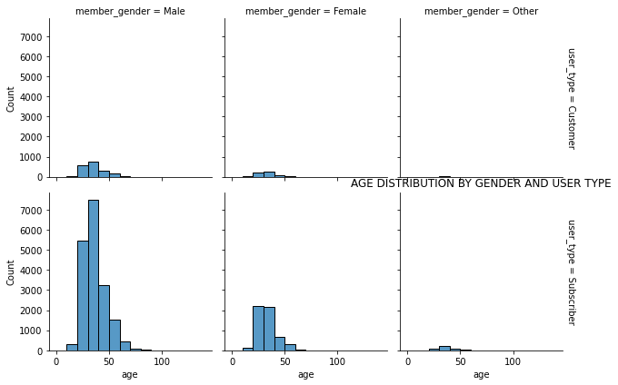

## TRIP DURATION BY USER TYPES FOR TOP 10 START STATIONS

> Surprisingly, customers are having a longer trip duration compared to subscribers. We can also see a regular trend of a little over 500 seconds for trips recorded for subscribers in all the top 10 start stations as against the irregular pattern observed in customers trip records in the top 10 start stations. The irregular trend observed for customers is possibly because most of the customers are one off users going to different destinations while most of the subscribers would likely have a fixed destination they go everyday like their place of work.

[figure not shown]

## AGE RANGE AND TRIP DURATION BY USER TYPES

A negative correlation is observed between trip duration and age range. This trend is similar for both customers and subscribers

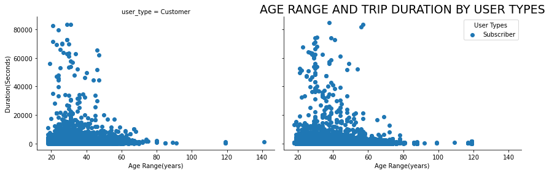